# Wavelets: Sparsity issue

Kushal K Dey

December 11, 2015

## Background

In this script, we start with wavelet modeling of a function. We discuss the concept of padding we use generously and try to get a sense of how the sparsity structure of wavelet transforms change depending on smoothness of the function. The intuition was that the more smoother the function is, the sparser the wavelet transform would be.

## Toy example function

```r
library(cellcycleR)
G <- 20;
num_cells <- 300;
amp_genes <- rep(10, G);
phi_genes <- runif(G, 0, 2*pi)
sigma_genes <- rchisq(G, 4);
cell_times_sim <- sort(sample(seq(0,2*pi, 2*pi/(num_cells-1)), num_cells, replace=FALSE));
cycle_data <- sim_sinusoidal_cycle(G, amp_genes, phi_genes, sigma_genes, cell_times_sim);
```

We generate a toy example of 20 sinusoidal gene expression patterns across 300 time points (synchronized for all genes). **We here focus on the sine curve function for one gene (the first gene)**. The pattern is given below

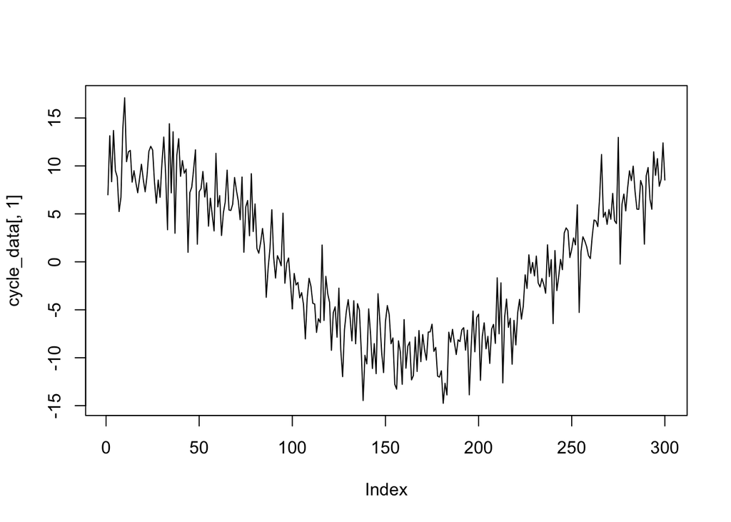

```r
plot(cycle_data[,1], type="l")
```

## Wavelet Transform

We now apply the wavelet transform using the *Wavethresh* package and see what wavelet coefficients we get and how good an approximation to the original function is obtained. However, to fit wavelet transform on a vector using this package, the length of the vector has to be a power of $2$. To deal with this, we use a truncation of the original vector or padding of the vector with zeros at the end.

### Truncating the function

We use the truncation

```r
library(wavethresh)
```

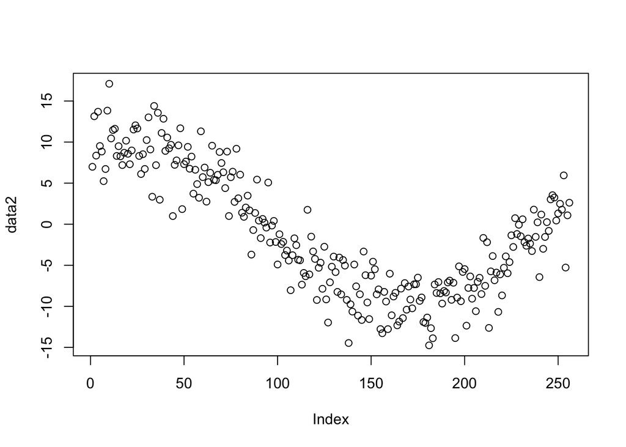

```r
data2=cycle_data[1:(2^8),1]
plot(data2)
```

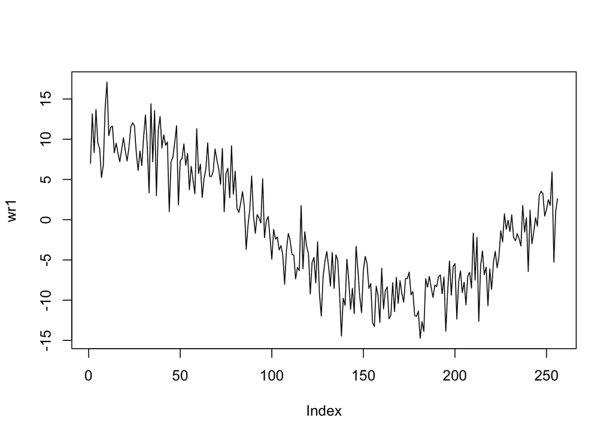

```r
wd1 <- wd(data2, filter.number = 1, family="DaubExPhase")
wr1 <- wr(wd1)
plot(wr1, type="l")
```

### Padding the function with zeros

We use the padding with 0 now.

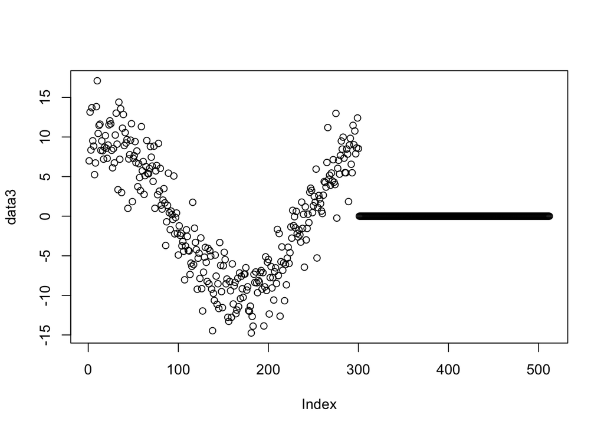

```r
data3=cycle_data[,1];
length(data3)<-2^ceiling(log(length(data3),2))
data3[is.na(data3)]<-0
plot(data3)
```

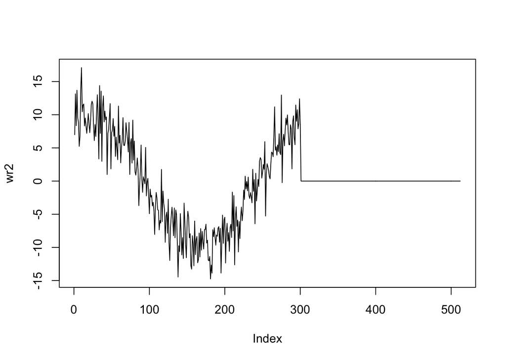

```r
wd2 <- wd(data3, filter.number = 1, family="DaubExPhase")
wr2 <- wr(wd2)
plot(wr2, type="l")
```

### Comparing sparsity

We look at how many non-zero wavelet coefficients are obtained, for the two scenarios- the one where the function is truncated and the other where it is padded with zeros.

```r
length(which(wd1$D > 0)) / length(wd1$D)
```

```
## [1] 0.5019608
```

```r
length(which(wd2$D > 0)) / length(wd2$D)
```

```
## [1] 0.295499
```

## Sample re-ordering

Now suppose that the original times of the sinusoidal time series pattern are not known. Instead, we know some permutation of the true times and the pattern of the gene expression under this permutation is much more haphazard. We wish to see how the sparsity of the wavelet transform under the sample re-ordered case compared compared to the one for the true order.

### An example use of re-ordering time series

We start with a permutation. The function plot of the re-ordering under thresholding.

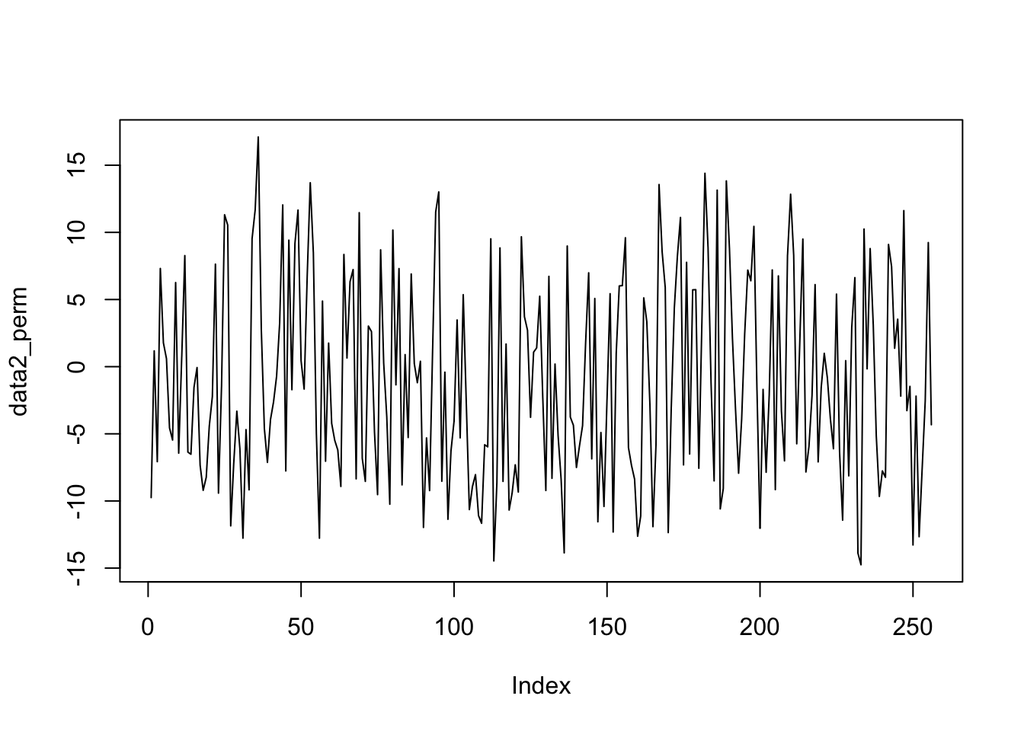

```r
data2_perm <- sample(data2,length(data2), replace=FALSE);
plot(data2_perm, type="l")
```

The function plot of the re-ordering of the function under padding.

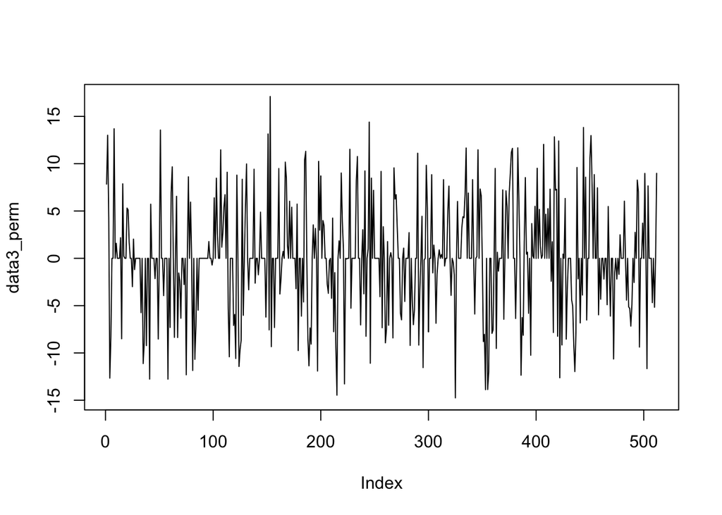

```r
data3_perm <- sample(data3,length(data3), replace=FALSE);
plot(data3_perm, type="l")
```

Now we model using wavelets. First, on the function with truncation.

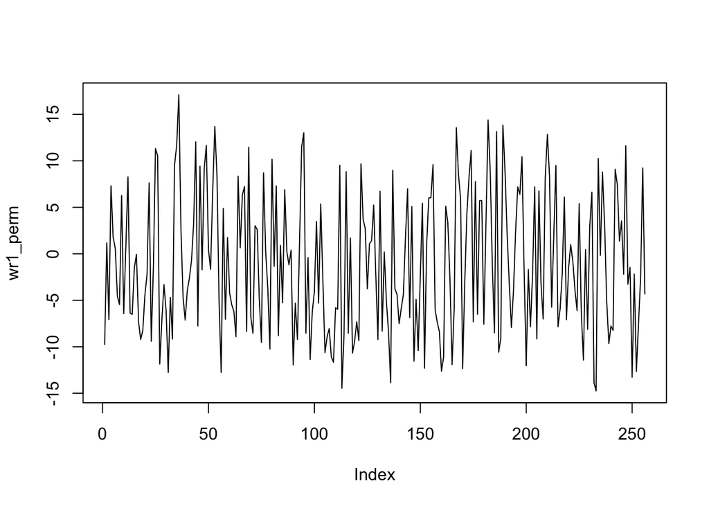

```r
wd1_perm <- wd(data2_perm, filter.number = 1, family="DaubExPhase")
wr1_perm <- wr(wd1_perm)
plot(wr1_perm, type="l")
```

Next, we do the same on the function with padding of zeros.

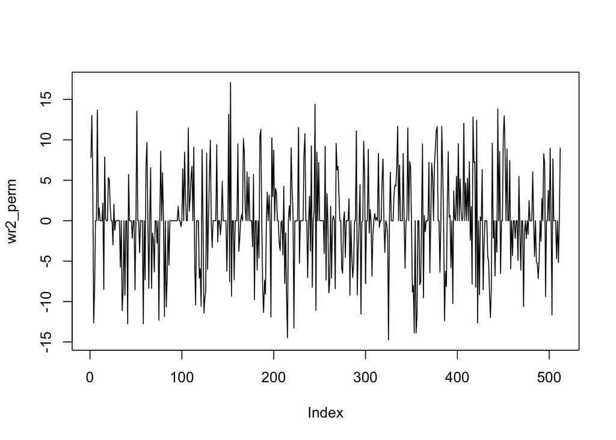

```r
wd2_perm <- wd(data3_perm, filter.number = 1, family="DaubExPhase")
wr2_perm <- wr(wd2_perm)
plot(wr2_perm, type="l")
```

Now check the number of non-zero wavelet coefficients

```r
length(which(wd1_perm$D > 0)) / length(wd1_perm$D)
```

```
## [1] 0.5019608
```

```r
length(which(wd2_perm$D > 0)) / length(wd2_perm$D)
```

```
## [1] 0.4657534
```

### Running multple instances of time re-ordering

We now repeat this sample permutation many times, obtain a distribution of number of non-zero wavelet coefficients in each case and then check where the true value (corresponding to actual ordering) lies.

```r
num_perms <- 500;
prop_wd1 <- array(0, num_perms);
prop_wd2 <- array(0, num_perms);

for(n in 1:num_perms)
{
  data2_perm <- sample(data2,length(data2), replace=FALSE);
  data3_perm <- sample(data3,length(data3), replace=FALSE);
  wd1_perm <- wd(data2_perm, filter.number = 1, family="DaubExPhase")
  wd2_perm <- wd(data3_perm, filter.number = 1, family="DaubExPhase")
  prop_wd1[n] = length(which(wd1_perm$D > 0)) / length(wd1_perm$D);
  prop_wd2[n] = length(which(wd2_perm$D > 0)) / length(wd2_perm$D);
}
```

We first plot the distribution of sparsity under time re-ordering for truncated function case.

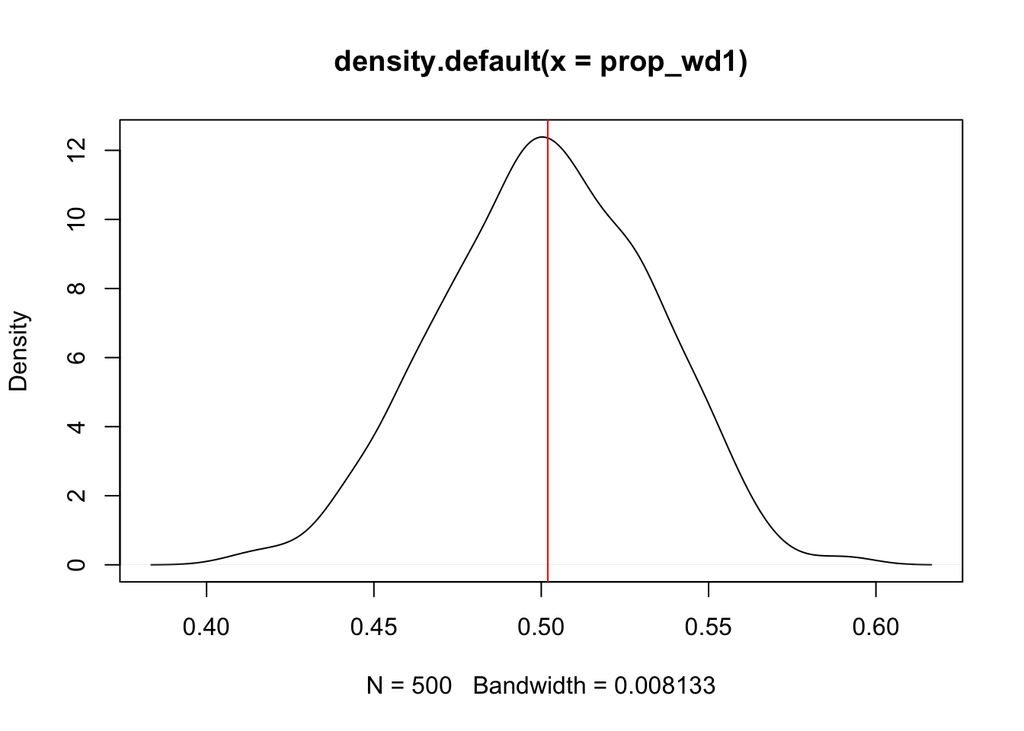

```r
plot(density(prop_wd1));
abline(v=length(which(wd1$D > 0)) / length(wd1$D), col="red")
```

Next, we do it for function with padding of zeros.

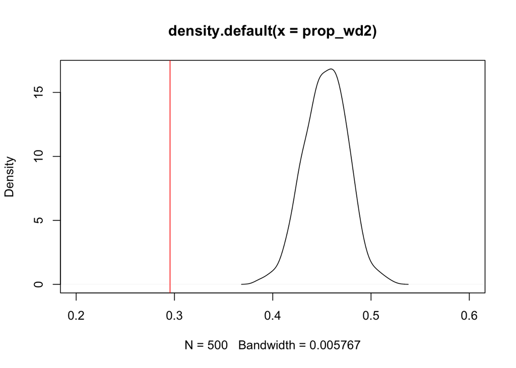

```r
plot(density(prop_wd2), xlim=c(0.2,0.6));
abline(v=length(which(wd2$D > 0)) / length(wd2$D), col="red")
```

## Conclusions

So, it seems that it is not really true that a false ordering which makes the pattern non-smooth corresponds to more non-zero wavelet coefficients. Our intuition seemed true for the case where the function was padded with zeros, but that couls be because there was a piecewise constant part under the true order which would lead to more sparsity. However, this did not seem true for the first scenario, where we just truncate the function.